# Clustering App-store reviews

The goal of this project is to experiment with clusetring customer reviews from App-store. I wanted to pick some controlversial app, so my choice fell on Tinder, which is a dating app. Clustering text data is very challenging task, however rewarding if done rightly. Clustering app reviews can help to find common themes of customer feedback, identify pain points for the users, and improve the app.

In this excersise, I want to group the reviews which have common themes or sentimentes, and make sure that reviews different from each other are in separate groups. I chose to work on Title of the reviews, rather then reviews themselves as it showed better clusetring quality.

### 1. Import libraries

```python
import pandas as pd
import numpy as np
import json
from app_store_scraper import AppStore
import string
import nltk
import re
from nltk.tokenize import word_tokenize
from nltk.corpus import stopwords
from sklearn.feature_extraction.text import TfidfVectorizer
from sklearn.feature_extraction.text import CountVectorizer
from yellowbrick.cluster import KElbowVisualizer
import matplotlib.pyplot as plt
from sklearn.metrics import silhouette_score
from sklearn.cluster import KMeans
from wordcloud import WordCloud
import matplotlib.pyplot as plt
import random
from yellowbrick.cluster import SilhouetteVisualizer
```

### 2. Scrap reviews from App-store

Fetching random reviews would have been perfect, however for simplicity taking 3000 which are being fetched automatically

```python
data = AppStore(country='us', app_name='tinder', app_id = '547702041')
data.review(how_many=3000)
```

```
2023-02-10 14:08:11,028 [INFO] Base - Initialised: AppStore('us', 'tinder', 547702041)
2023-02-10 14:08:11,029 [INFO] Base - Ready to fetch reviews from: https://apps.apple.com/us/app/tinder/id547702041
2023-02-10 14:08:16,245 [INFO] Base - [id:547702041] Fetched 300 reviews (300 fetched in total)
2023-02-10 14:08:21,807 [INFO] Base - [id:547702041] Fetched 620 reviews (620 fetched in total)
2023-02-10 14:08:27,347 [INFO] Base - [id:547702041] Fetched 920 reviews (920 fetched in total)
2023-02-10 14:08:32,911 [INFO] Base - [id:547702041] Fetched 1240 reviews (1240 fetched in total)
2023-02-10 14:08:38,774 [INFO] Base - [id:547702041] Fetched 1440 reviews (1440 fetched in total)
2023-02-10 14:08:44,499 [INFO] Base - [id:547702041] Fetched 1640 reviews (1640 fetched in total)
2023-02-10 14:08:50,203 [INFO] Base - [id:547702041] Fetched 1940 reviews (1940 fetched in total)
2023-02-10 14:08:55,854 [INFO] Base - [id:547702041] Fetched 2240 reviews (2240 fetched in total)
2023-02-10 14:09:01,770 [INFO] Base - [id:547702041] Fetched 2560 reviews (2560 fetched in total)
2023-02-10 14:09:07,309 [INFO] Base - [id:547702041] Fetched 2860 reviews (2860 fetched in total)
2023-02-10 14:09:09,817 [INFO] Base - [id:547702041] Fetched 3000 reviews (3000 fetched in total)
```

### 3. Convert result to a DataFrame

```python
data = pd.DataFrame(np.array(data.reviews),columns=['review'])
data = data.join(pd.DataFrame(data.pop('review').tolist()))
data.head()
```

|  | date | review | rating | isEdited | title | userName | developerResponse |
| --- | --- | --- | --- | --- | --- | --- | --- |
| 0 | 2022-05-28 15:04:00 | I used to unironically like Tinder, even at it... | 2 | False | Tinder Gold Is No Longer Worth Your Money | WordiestTomb | NaN |
| 1 | 2022-07-20 03:23:26 | I’ve had this app for a while and though I was... | 1 | False | To each is own‼️ | Berdeisha | NaN |
| 2 | 2022-04-17 17:39:14 | When tinder first came out it was nearly free ... | 1 | False | Very much a sca these days | Tyler Sandy | NaN |
| 3 | 2022-03-04 19:37:56 | Within 48 hrs of having downloaded the app (mo... | 1 | False | They Can Shut You Down With No Explanation | Mr. McGuillacutty | NaN |
| 4 | 2022-09-01 04:33:02 | What can I say? What should I say? It doesn’t ... | 1 | False | Deserves shutting down, it’s a scam. | Dako_the_Austinite | NaN |

### 4. Text pre-processing

To make sure review titles are suitable for clustering, text pre-processing is a must. Noise in text data negatively impacts quality of clustering.  
Text pre-processing steps invlove:

- making letters lowercase
- remove signs and punctuations
- tokenizing text (breaking down text into individual words)
- remove stop words from the text

```python
#nltk.download('punkt')
#nltk.download('stopwords')


def text_pre_process(text):

    text = text.lower()
    text = text.translate(str.maketrans("", "", string.punctuation))
    text = re.sub(r'[^\w\s]', '', text)
    tokens = nltk.word_tokenize(text)
    stop_words = set(stopwords.words("english"))
    tokens = [word for word in tokens if word not in stop_words]
    text = " ".join(tokens)
    return text

data["title"] = data["title"].apply(text_pre_process)
```

```python
data.head()
```

|  | date | review | rating | isEdited | title | userName | developerResponse |
| --- | --- | --- | --- | --- | --- | --- | --- |
| 0 | 2022-05-28 15:04:00 | I used to unironically like Tinder, even at it... | 2 | False | tinder gold longer worth money | WordiestTomb | NaN |
| 1 | 2022-07-20 03:23:26 | I’ve had this app for a while and though I was... | 1 | False |  | Berdeisha | NaN |
| 2 | 2022-04-17 17:39:14 | When tinder first came out it was nearly free ... | 1 | False | much sca days | Tyler Sandy | NaN |
| 3 | 2022-03-04 19:37:56 | Within 48 hrs of having downloaded the app (mo... | 1 | False | shut explanation | Mr. McGuillacutty | NaN |
| 4 | 2022-09-01 04:33:02 | What can I say? What should I say? It doesn’t ... | 1 | False | deserves shutting scam | Dako_the_Austinite | NaN |

### 5. Vectorizing

If we want to apply machine learning algorithms on text data (sequance of words), it is necesasary to vectorize our data - transform text into numerical representaions. As backbone of each clusetring method is to calculate similarity between datapoints, it can`t be done directly on text data.

For vectorizing text data, there are two main vectorization methods to use:

1. **CountVectorizer**

> It creates a bag-of-words representation of the text data, where each dimension of the vector represents a word, and the value in each dimension represents the number of times that word appears in the document.

2. **TF-IDF**

> It creates a representation where each dimension of the vector represents a word, and the value in each dimension represents the relative importance of that word in the document with respect to all documents in the corpus.

**My choice**

Intuitively, I firstly picked TF-IDF method, as it is more sophisticated and is able to identify relative importance of a word, not only frequency in the document as in case of **CountVectoriser**. However to my surprise, CountVectorizer gave much better results in terms of both a) clustering quality measures - Silhouette and CalinskiHarabasz scores and b) results made more sense, which will be discussed later on, so I sticked to a simpler method.

Here we see that sparse matrix object is created as a result

```python
reviews = data['title']
# 1. Vectorizing - transforming to bag-of-words (frequency)

# 2. TF-IDF representation (frequency + weight)
#vectorizer = TfidfVectorizer()
#review_vectors = vectorizer.fit_transform([' '.join(token) for token in tokens])

reviews = data['title'].tolist()
vectorizer = CountVectorizer()
review_vectors = vectorizer.fit_transform(reviews)
review_vectors
```

```
<3000x1927 sparse matrix of type '<class 'numpy.int64'>'
	with 8782 stored elements in Compressed Sparse Row format>
```

### 6. Find optimal number of clusters

This can be done in a few ways. Two most commonly used are Elbow Method and Silhouette score.

**1. Elbow Method</br>**

- Within-cluster sum of squares (WCSS) are being plotted against the number of clusters.
- Then it finds the "elbow" point, where the WCSS starts to decrease at a slower rate
- So adding more clusters does not significantly reduce the WCSS hence does not improve qulaity of clustering.
- The number of clusters corresponding to the elbow point is considered the optimal number of clusters.

It is rather heruistic approach. It is not most optimal way to find a good k, as there can be multiple elbows in the plot or it is not clearly visible. I used fancy Yellowbrick library, where quality scores are calculated under the hook, and it suggets optimal values. In our case the plot looks a bit confusing, and is suggesting 5 clusters.

Let`s try a more sophisticated method

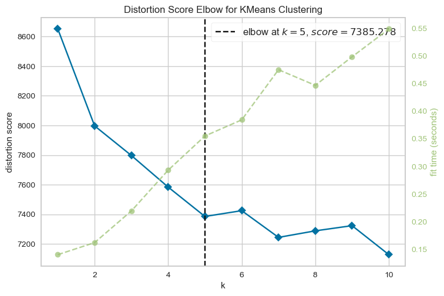

```python
# Kmeans
model = KMeans()

# KElbowVizualizer from yellowbricks. You can also choose a distance metric e.g. distance_metric = "eucledian"
visualizer = KElbowVisualizer(model, k=(1,11))
visualizer.fit(review_vectors.toarray())
visualizer.show()
```

**2. Silhouete score</br>**

The silhouette score is a metric used to evaluate the quality of clustering in unsupervised learning. It measures the similarity of an object to its own cluster compared to other clusters.

For each sample in the data, the SS is calculated like that:

- Computes **intra-cluster similarity**, which is an average distance between the sample and all other points in its own cluster
- Computes **inter-cluster separation**, which is the average distance of the sample vs. all other points in the closest other cluster.
- SS for the sample is difference between the inter-cluster separation and the intra-cluster similarity, divided by the maximum of these two values:

**SS = (inter_cluster_separation - intra_cluster_similarity) / max(inter_cluster_separation, intra_cluster_similarity)**

For a set of samples, it is the average of the silhouette scores of all the samples. The silhouette score ranges from -1 to 1:

- 1: perfect clustering
- 0: overlapping clusters
- -1: poor clustering

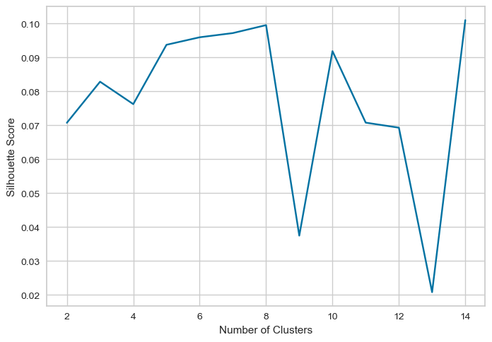

```python
import matplotlib.pyplot as plt
from sklearn.metrics import silhouette_score
from sklearn.cluster import KMeans


range_n_clusters = range(2, 15)


silhouette_scores = []


for n_clusters in range_n_clusters:

    kmeans = KMeans(n_clusters=n_clusters)
    kmeans.fit(review_vectors)


    silhouette_avg = silhouette_score(review_vectors, kmeans.labels_)

    silhouette_scores.append(silhouette_avg)

plt.plot(range_n_clusters, silhouette_scores)
plt.xlabel('Number of Clusters')
plt.ylabel('Silhouette Score')
plt.show()
```

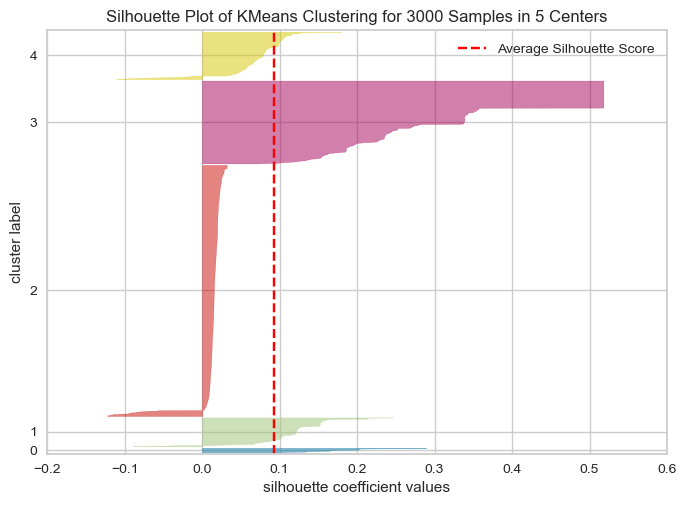

```python
model = KMeans(n_clusters=5)


model.fit(review_vectors.toarray())


visualizer = SilhouetteVisualizer(model, colors='yellowbrick')


visualizer.fit(review_vectors.toarray())


visualizer.show()
```

I decided to choose k as 5, given Elbow Method & Silhouette score results. I didn`t go for higher k, as in SS plot, improvement from k=5 to bigger k is not significant, plus our sample size = 3000 is not so large for the headlines.

### Results

I used **WorldCloud library** to visualize the results of clusetring to see if we can gather common themes based on word frequency in each cluster.

** Finally, I changed vectorizer method from CountVectorizer to TF-IDF. Even though it reduces the silhouette score, it gives cleaner results in terms of cluster presentation. I assume it happens as less important words get removed from the cloud.

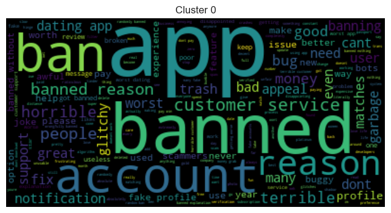

[figure not shown]

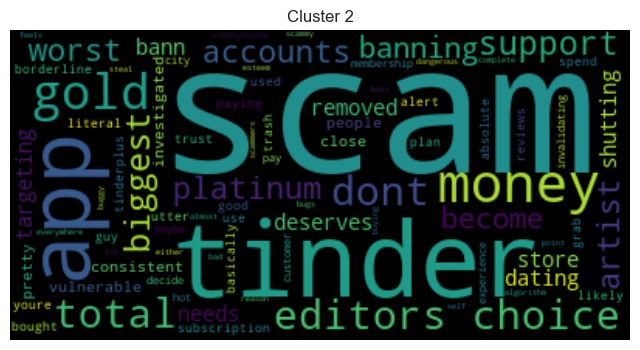

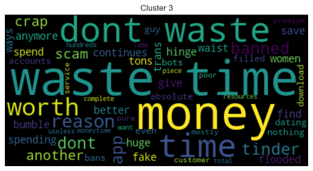

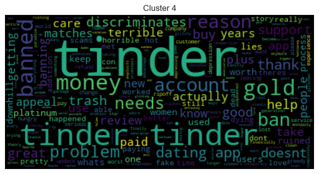

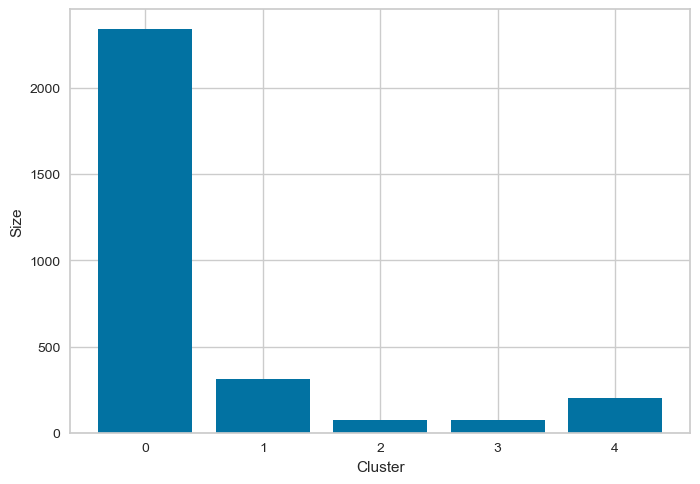

```python
vectorizer = TfidfVectorizer()
review_vectors = vectorizer.fit_transform(reviews)

kmeans = KMeans(n_clusters=5)
kmeans.fit(review_vectors)


labels = kmeans.labels_

for i in range(5):
    cluster_reviews = [reviews[j] for j in range(len(reviews)) if labels[j] == i]
    text = ' '.join(cluster_reviews)
    wordcloud = WordCloud().generate(text)
    plt.imshow(wordcloud, interpolation='bilinear')
    plt.axis("off")
    plt.title("Cluster {}".format(i))
    plt.show()


cluster_sizes = np.unique(labels, return_counts=True)[1]


plt.bar(np.arange(len(cluster_sizes)), cluster_sizes)
plt.xlabel("Cluster")
plt.ylabel("Size")
plt.show()
```

### Conclusion

After this experiment, I can conclude that clustering text data is a challenging task, involving a lot of text pre-processing. Data of this type contains much more noise and dimensions, hence it is hard to apply common dimension reduction techniques on this type. Cluster sizes are evidently uneqal with the first cluster being much larger than others. I tried several techniques to fix that, including different vectorization method, trying various distance metrics good specifically for text such as Coisine distance, however it did not make clusetrs moge equal in size. Incraesing number of clusetrs did help, but they were much more overlapping and situation with 1 very large cluster vs other smaller persisted. Despite qulaity measure scores being not so ideal and cluster size being uneven, I still think this experiment was valuable as it allowed to extract common themes from app-store reviews and I learned a lot on the way.